# PSTAT126: Part 3 Multiple Linear Model

## Influential Points: Cook’s Distance

Although graphically speaking our three influential points seem to look pretty high, the fact that it remained below 0.3 seemed to indicate that the three influential points did not have a significant affect on the skewing of our model.

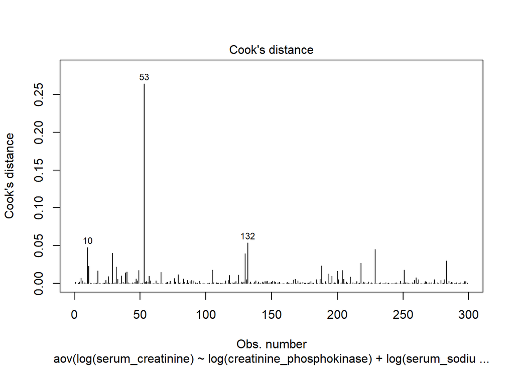

Influential points

```r
anova_multi <- aov(log(serum_creatinine) ~ log(creatinine_phosphokinase) + log(serum_sodium), data=heart)
plot(anova_multi, 4) # cooks distance
```

## conclusion: interesting findings

In conclusion, creating a multiple linear model, although it gave a broader picture into the relationships among a swathe of variables, showed low correlation. Although our models were not very linearly correlated, the predictors in our model gave good indications as to the statistical significance of some predictors in our model. Our models did show some influential points that may have skewed our data, however due to the decent number of observations present in our dataset, the 3 influential points found in our model did not seem to create too much of an affect on our model. Overall, the variables present in the dataset, and the relationships there in should be taken with a grain of salt. They do not seem to show any strong correlation as a result of the high RMSE so rather than seeing the predictive power of the model, the models themselves should be seen as showing some correlation but not a lot. These models might also be indicating some symptom responses as a result of unknown interaction variables that are not present in our dataset, or perhaps there just is not much of a correlation.